# Logistic Regression

On January 28, 1986, the NASA space shuttle Challenger had an accident. The vehicle broke apart and disintegrated at 73 seconds into its flight, leading to the deaths of its seven crew members. The accident had serious consequences for the NASA credibility and resulted in an interruption of 32 months in the shuttle program. The Presidential Rogers Commission (formed by astronaut Neil A. Armstrong and Nobel laureate Richard P. Feynman, among others) was created in order to investigate the causes of the disaster.

The Rogers Commission elaborated a report (Presidential Commission on the Space Shuttle Challenger Accident 1986) with all the findings. The commission determined that the disintegration began with the failure of an O-ring seal in the solid rocket motor due to the unusually cold temperature (−0.6 Celsius degrees) during the launch. This failure produced a breach of burning gas through the solid rocket motor that compromised the whole shuttle structure, resulting in its disintegration due to the extreme aerodynamic forces.

This space shuttle used two booster rockets to help lift it into orbit. Each booster rocket consists of several pieces whose joints are sealed with rubber O-rings (0.28 inches wide and 37.5 feet in diameter), which are designed to prevent the release of hot gases produced during combustion. Each booster contains 3 primary Orings (for a total of 6 for the orbiter).

In the 23 previous flights for which there were data (the hardware for one flight was lost at sea), the O-rings were examined for damage.

One interesting question is the relationship of O-ring damage to temperature (particularly since it was (forecasted to be) cold — 31F — on the morning of January 28, 1986). There was a good deal of discussion among the Morton Thiokol (https://en.wikipedia.org/wiki/Thiokol (https://en.wikipedia.org/wiki/Thiokol)) engineers the previous day as to whether the flight should go on as planned or not.

Let’s analyze the dataset challenger challenger.csv

**Our goal is to analyze the relationship between temperature and the probability of O-ring failure.**

```python
import warnings
warnings.filterwarnings('ignore')
```

```python
import scipy as scp
import sklearn
from sklearn.model_selection import train_test_split
from sklearn.linear_model import LogisticRegression
from sklearn.metrics import classification_report
from sklearn import metrics
from sklearn.metrics import confusion_matrix
```

```python
import statsmodels.api as sm
import matplotlib.pyplot as plt
import numpy as np
from scipy.special import expit
from sklearn.linear_model import LogisticRegression
```

```python
from sklearn.model_selection import train_test_split
from sklearn.model_selection import RepeatedStratifiedKFold
from sklearn.model_selection import cross_val_score
from sklearn.discriminant_analysis import QuadraticDiscriminantAnalysis
from sklearn import datasets
```

```python
import pandas as pd
df = pd.read_csv('challenger.csv')
```

```python
#Creating our dependent variable IsDamaged
def Classification(Damaged):
    if Damaged > 0:
        return 1
    else:
        return 0

df['IsDamaged']=df['Damaged'].apply(Classification)
```

```python
df.head()
```

|  | Row | Date | Temp | Damaged | O-rings | IsDamaged |
| --- | --- | --- | --- | --- | --- | --- |
| 0 | 1 | 4/12/1981 | 66 | 0 | 6 | 0 |
| 1 | 2 | 11/12/1981 | 70 | 1 | 6 | 1 |
| 2 | 3 | 3/22/1982 | 69 | 0 | 6 | 0 |
| 3 | 4 | 11/11/1982 | 68 | 0 | 6 | 0 |
| 4 | 5 | 4/4/1983 | 67 | 0 | 6 | 0 |

**Perform logistic regression analysis**

```python
X = df[['Temp']]
y = df[['IsDamaged']]
log_reg = sm.Logit(y, X).fit()
print(log_reg.summary())
```

```
Optimization terminated successfully.
         Current function value: 0.592665
         Iterations 4
                           Logit Regression Results
==============================================================================
Dep. Variable:              IsDamaged   No. Observations:                   23
Model:                          Logit   Df Residuals:                       22
Method:                           MLE   Df Model:                            0
Date:                Thu, 31 Jul 2025   Pseudo R-squ.:                 0.03554
Time:                        10:54:02   Log-Likelihood:                -13.631
converged:                       True   LL-Null:                       -14.134
Covariance Type:            nonrobust   LLR p-value:                       nan
==============================================================================
                 coef    std err          z      P>|z|      [0.025      0.975]
------------------------------------------------------------------------------
Temp          -0.0136      0.007     -2.033      0.042      -0.027      -0.000
==============================================================================
```

The slope coefficient is the expected change in log odds of having the outcome (IsDamaged) per unit change in Temp.

```python
prediction = log_reg.predict(X)
```

```python
df['prediction'] = prediction
```

```python
df['prediction_probability'] = df.prediction * df.Damaged/df['O-rings']
df
```

|  | Row | Date | Temp | Damaged | O-rings | IsDamaged | prediction | prediction_probability |
| --- | --- | --- | --- | --- | --- | --- | --- | --- |
| 0 | 1 | 4/12/1981 | 66 | 0 | 6 | 0 | 0.290114 | 0.000000 |
| 1 | 2 | 11/12/1981 | 70 | 1 | 6 | 1 | 0.279073 | 0.046512 |
| 2 | 3 | 3/22/1982 | 69 | 0 | 6 | 0 | 0.281809 | 0.000000 |
| 3 | 4 | 11/11/1982 | 68 | 0 | 6 | 0 | 0.284562 | 0.000000 |
| 4 | 5 | 4/4/1983 | 67 | 0 | 6 | 0 | 0.287330 | 0.000000 |
| 5 | 6 | 6/18/1983 | 72 | 0 | 6 | 0 | 0.273651 | 0.000000 |
| 6 | 7 | 8/30/1983 | 73 | 0 | 6 | 0 | 0.270964 | 0.000000 |
| 7 | 8 | 11/28/1983 | 70 | 0 | 6 | 0 | 0.279073 | 0.000000 |
| 8 | 9 | 2/3/1984 | 57 | 1 | 6 | 1 | 0.315872 | 0.052645 |
| 9 | 10 | 4/6/1984 | 63 | 1 | 6 | 1 | 0.298562 | 0.049760 |
| 10 | 11 | 8/30/1984 | 70 | 1 | 6 | 1 | 0.279073 | 0.046512 |
| 11 | 12 | 10/5/1984 | 78 | 0 | 6 | 0 | 0.257782 | 0.000000 |
| 12 | 13 | 11/8/1984 | 67 | 0 | 6 | 0 | 0.287330 | 0.000000 |
| 13 | 14 | 1/24/1985 | 53 | 2 | 6 | 1 | 0.327707 | 0.109236 |
| 14 | 15 | 4/12/1985 | 67 | 0 | 6 | 0 | 0.287330 | 0.000000 |
| 15 | 16 | 4/29/1985 | 75 | 0 | 6 | 0 | 0.265641 | 0.000000 |
| 16 | 17 | 6/17/1985 | 70 | 0 | 6 | 0 | 0.279073 | 0.000000 |
| 17 | 18 | 7/29/1985 | 81 | 0 | 6 | 0 | 0.250077 | 0.000000 |
| 18 | 19 | 8/27/1985 | 76 | 0 | 6 | 0 | 0.263005 | 0.000000 |
| 19 | 20 | 10/3/1985 | 79 | 0 | 6 | 0 | 0.255197 | 0.000000 |
| 20 | 21 | 10/30/1985 | 75 | 2 | 6 | 1 | 0.265641 | 0.088547 |
| 21 | 22 | 11/26/1985 | 76 | 0 | 6 | 0 | 0.263005 | 0.000000 |
| 22 | 23 | 1/12/1986 | 58 | 1 | 6 | 1 | 0.312950 | 0.052158 |

# Variance Inflation Factor

When modeling, we want predictor variables that are correlated with the response variable. We do not want predictors correlated with each other. Interpredictor correlation may result in collinearity (also called multicollinearity), and can destabilize a model. If two predictor variables are nearly identical, our $\beta$ coefficients may change arbitrarily and cause the standard error (SE) to increase, hiding significant relationships between response and predictors. We can test for collinearity by computing a Variance Inflation Factor (VIF), which measures the association (correlation) among the predictor variables - excluding the response variable. It is given by:

$$ VIF = \frac{1}{(1-R^2_j)} $$

$R^2$ measures how much one predictor is correlated with other predictors. When a predictor is totally uncorrelated (independent of) with others, then VIF = 1. As predictors approach complete collinearity (or extreme multicollinearity) with other predictors,VIF $\rightarrow~\infty$.

Some people believe inter-predictor correlation may be too high when VIF becomes greater than 2.5, while others flag the correlation as problematic when VIF becomes greater than 10. Here, we will use VIF $> 10.$

**Calculate VIF using predictors in the data `prostate_cancer.csv`.**

**Compute the coefficient of determination $R^2_j$ by regressing smoothness over the other predictors in `prostate_cancer.csv`, but not for the response variable `diagnosis_result`.**

```python
df2 = pd.read_csv('prostate_cancer.csv')
df2.head()
```

|  | id | diagnosis_result | radius | texture | perimeter | area | smoothness | compactness | symmetry | fractal_dimension |
| --- | --- | --- | --- | --- | --- | --- | --- | --- | --- | --- |
| 0 | 1 | M | 23 | 12 | 151 | 954 | 0.143 | 0.278 | 0.242 | 0.079 |
| 1 | 2 | B | 9 | 13 | 133 | 1326 | 0.143 | 0.079 | 0.181 | 0.057 |
| 2 | 3 | M | 21 | 27 | 130 | 1203 | 0.125 | 0.160 | 0.207 | 0.060 |
| 3 | 4 | M | 14 | 16 | 78 | 386 | 0.070 | 0.284 | 0.260 | 0.097 |
| 4 | 5 | M | 9 | 19 | 135 | 1297 | 0.141 | 0.133 | 0.181 | 0.059 |

```python
x = df2[['radius','texture', 'perimeter','area','compactness', 'symmetry', 'fractal_dimension']]
y = df2['smoothness']
x = sm.add_constant(x)
lmFit = sm.OLS(y, x).fit()
print(lmFit.summary())
print('R2 of smoothness is', lmFit.rsquared)
```

```
                            OLS Regression Results
==============================================================================
Dep. Variable:             smoothness   R-squared:                       0.302
Model:                            OLS   Adj. R-squared:                  0.249
Method:                 Least Squares   F-statistic:                     5.692
Date:                Thu, 31 Jul 2025   Prob (F-statistic):           1.75e-05
Time:                        10:54:02   Log-Likelihood:                 298.99
No. Observations:                 100   AIC:                            -582.0
Df Residuals:                      92   BIC:                            -561.1
Df Model:                           7
Covariance Type:            nonrobust
=====================================================================================
                        coef    std err          t      P>|t|      [0.025      0.975]
-------------------------------------------------------------------------------------
const                -0.0093      0.033     -0.283      0.778      -0.075       0.056
radius               -0.0002      0.000     -0.760      0.449      -0.001       0.000
texture               0.0002      0.000      0.997      0.321      -0.000       0.001
perimeter             0.0007      0.000      1.924      0.058   -2.12e-05       0.001
area              -2.653e-05   2.18e-05     -1.214      0.228   -6.99e-05    1.69e-05
compactness          -0.0771      0.064     -1.197      0.235      -0.205       0.051
symmetry              0.1018      0.059      1.726      0.088      -0.015       0.219
fractal_dimension     0.8778      0.372      2.358      0.020       0.138       1.617
==============================================================================
Omnibus:                       13.905   Durbin-Watson:                   2.168
Prob(Omnibus):                  0.001   Jarque-Bera (JB):               47.726
Skew:                          -0.150   Prob(JB):                     4.33e-11
Kurtosis:                       6.371   Cond. No.                     2.31e+05
==============================================================================

Notes:
[1] Standard Errors assume that the covariance matrix of the errors is correctly specified.
[2] The condition number is large, 2.31e+05. This might indicate that there are
strong multicollinearity or other numerical problems.
R2 of smoothness is 0.3021991198810753
```

```python
r2 = lmFit.rsquared
smoothness_VIF = 1/(1-r2)
print('smoothness VIF is', smoothness_VIF)
```

```
smoothness VIF is 1.4330735722625803
```

```python
#Create VIF function
def VIF_function(variable):
    x = df2[df2.columns.difference(['diagnosis_result', 'id', variable])]
    y = df2[variable]
    x = sm.add_constant(x)
    lmFit = sm.OLS(y, x).fit()
    r2 = lmFit.rsquared
    vif = 1/(1-r2)
    return variable, vif
```

```python
print(VIF_function('smoothness'))
print(VIF_function('radius'))
print(VIF_function('texture'))
print(VIF_function('perimeter'))
print(VIF_function('area'))
print(VIF_function('compactness'))
print(VIF_function('symmetry'))
print(VIF_function('fractal_dimension'))
```

```
('smoothness', 1.4330735722625805)
('radius', 1.1132817459441136)
('texture', 1.050930703175846)
('perimeter', 41.027989227504705)
('area', 30.481802966088505)
('compactness', 9.683470104799182)
('symmetry', 2.0941058653406497)
('fractal_dimension', 6.004524042501021)
```

The VIF for perimeter and area exceeds 10 which means that there is collinearity. To fix this, we should remove perimeter and area from the analysis

# Logistic Regression, LDA and QDA

The Iris dataset was used in R.A. Fisher’s classic 1936 paper, The Use of Multiple Measurements in Taxonomic Problems, and can also be found on the UCI Machine Learning Repository.

It includes three iris species with 50 samples each as well as some properties about each flower. One flower species is linearly separable from the other two, but the other two are not linearly separable from each other.

**Classify iris plants into three species in this dataset.**

```python
df3 = pd.read_csv('iris.csv')
df3.Species.unique()
```

```
array(['Iris-setosa', 'Iris-versicolor', 'Iris-virginica'], dtype=object)
```

```python
def Classification(Species):
    if Species == 'Iris-setosa':
        return 1
    elif Species == 'Iris-versicolor':
        return 2
    elif Species == 'Iris-virginica':
        return 3

df3['SIZE_SPECIES']=df3['Species'].apply(Classification)
```

```python
df3
```

|  | Id | SepalLengthCm | SepalWidthCm | PetalLengthCm | PetalWidthCm | Species | SIZE_SPECIES |
| --- | --- | --- | --- | --- | --- | --- | --- |
| 0 | 1 | 5.1 | 3.5 | 1.4 | 0.2 | Iris-setosa | 1 |
| 1 | 2 | 4.9 | 3.0 | 1.4 | 0.2 | Iris-setosa | 1 |
| 2 | 3 | 4.7 | 3.2 | 1.3 | 0.2 | Iris-setosa | 1 |
| 3 | 4 | 4.6 | 3.1 | 1.5 | 0.2 | Iris-setosa | 1 |
| 4 | 5 | 5.0 | 3.6 | 1.4 | 0.2 | Iris-setosa | 1 |
| ... | ... | ... | ... | ... | ... | ... | ... |
| 145 | 146 | 6.7 | 3.0 | 5.2 | 2.3 | Iris-virginica | 3 |
| 146 | 147 | 6.3 | 2.5 | 5.0 | 1.9 | Iris-virginica | 3 |
| 147 | 148 | 6.5 | 3.0 | 5.2 | 2.0 | Iris-virginica | 3 |
| 148 | 149 | 6.2 | 3.4 | 5.4 | 2.3 | Iris-virginica | 3 |
| 149 | 150 | 5.9 | 3.0 | 5.1 | 1.8 | Iris-virginica | 3 |

150 rows × 7 columns

```python
X = df3.drop(['Species','Id', 'SIZE_SPECIES'], axis=1)
y = df3['SIZE_SPECIES']
```

```python
X_train, X_test, y_train, y_test = sklearn.model_selection.train_test_split(X, y, test_size = 0.20, random_state = 5)
```

```python
#Logistic regression using training set
model1 = LogisticRegression(random_state=5, multi_class='multinomial', penalty='none', solver='newton-cg').fit(X_train, y_train)
```

**Compute numerical and graphical summaries of the (training) data.**

```python
training_data = X_train.copy()
```

```python
training_data['SIZE_SPECIES'] = y_train.copy()
```

```python
training_data.describe()
```

|  | SepalLengthCm | SepalWidthCm | PetalLengthCm | PetalWidthCm | SIZE_SPECIES |
| --- | --- | --- | --- | --- | --- |
| count | 120.000000 | 120.000000 | 120.000000 | 120.000000 | 120.000000 |
| mean | 5.838333 | 3.069167 | 3.690833 | 1.170833 | 1.975000 |
| std | 0.841186 | 0.456659 | 1.780709 | 0.770506 | 0.824647 |
| min | 4.300000 | 2.000000 | 1.000000 | 0.100000 | 1.000000 |
| 25% | 5.100000 | 2.800000 | 1.500000 | 0.300000 | 1.000000 |
| 50% | 5.750000 | 3.000000 | 4.250000 | 1.300000 | 2.000000 |
| 75% | 6.500000 | 3.400000 | 5.100000 | 1.800000 | 3.000000 |
| max | 7.900000 | 4.400000 | 6.900000 | 2.500000 | 3.000000 |

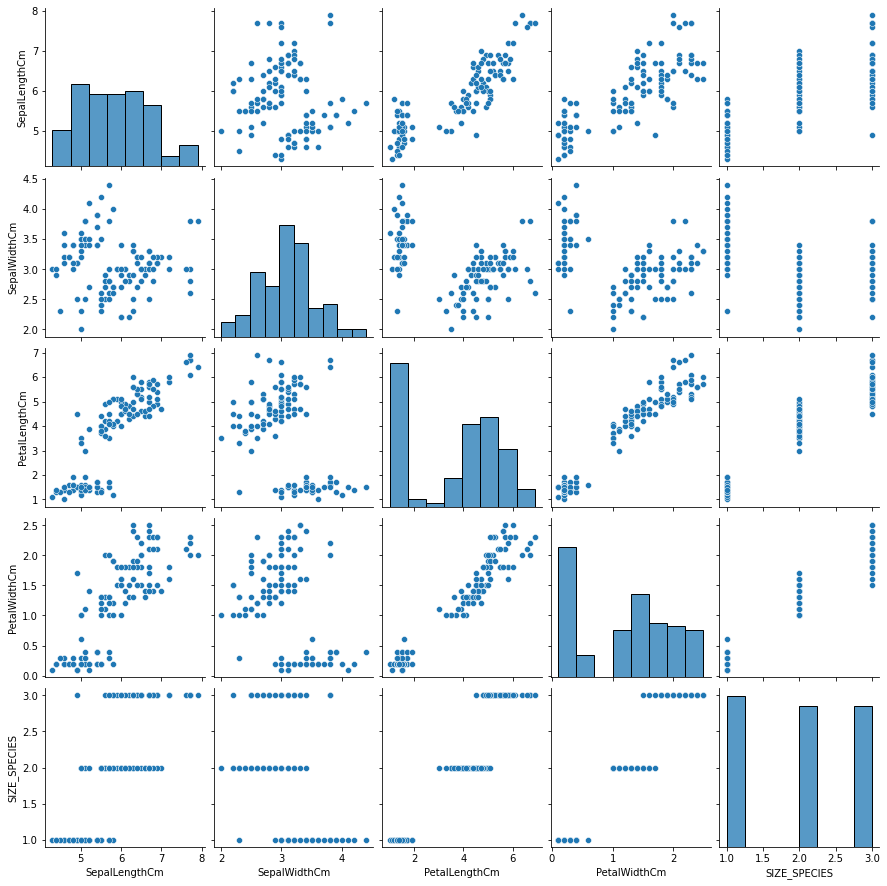

```python
import seaborn as sns
import matplotlib.pyplot as plt
sns.pairplot(training_data)
```

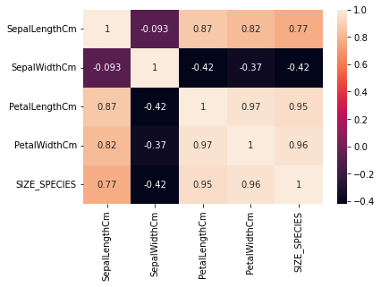

```python
corr_matrix = training_data.corr()
sns.heatmap(corr_matrix, annot=True)
plt.show()
```

**Compute accuracy and a confusion matrix on the training set and test set separately.**

```python
#Training set results
preds = model1.predict(X_train)
```

```python
confusion_matrix(y_train, preds)
```

```
array([[42,  0,  0],
       [ 0, 39,  0],
       [ 0,  0, 39]])
```

```python
print('Accuracy Score:', metrics.accuracy_score(y_train, preds))
#Prediction on Training set is 100% accurate
```

```
Accuracy Score: 1.0
```

```python
#Test set results
preds = model1.predict(X_test)
```

```python
confusion_matrix(y_test, preds)
```

```
array([[ 8,  0,  0],
       [ 0, 11,  0],
       [ 0,  2,  9]])
```

```python
#Accuracy of test
print('Accuracy Score:', metrics.accuracy_score(y_test, preds))

#Compared to the prediction on the training set, the accuracy is lower, the model had 2 mispredictions.
```

```
Accuracy Score: 0.9333333333333333
```

We can also evaluate how well the model performed outside of the sample by using repeated stratified k-fold cross validation.

```python
model1 = LogisticRegression(penalty=None)
```

```python
from sklearn.model_selection import cross_val_score, RepeatedStratifiedKFold
import numpy as np

cv = RepeatedStratifiedKFold(n_splits=10, n_repeats=3, random_state=1)
scores = cross_val_score(model1, X, y, scoring='accuracy', cv=cv, n_jobs=-1)
print(np.mean(scores))
```

```
0.9755555555555556
```

# Linear Discriminant Analysis (LDA)

```python
from sklearn.model_selection import train_test_split
from sklearn.model_selection import RepeatedStratifiedKFold
from sklearn.model_selection import cross_val_score
from sklearn.discriminant_analysis import LinearDiscriminantAnalysis
from sklearn import datasets
import matplotlib.pyplot as plt
import pandas as pd
import numpy as np
```

```python
model2 = LinearDiscriminantAnalysis()
model2.fit(X_train, y_train)
```

```
LinearDiscriminantAnalysis()
```

```python
preds = model2.predict(X_test)
```

```python
confusion_matrix(y_test, preds)
```

```
array([[ 8,  0,  0],
       [ 0, 10,  1],
       [ 0,  1, 10]])
```

```python
#accuracy on the test data
print('Accuracy Score:', metrics.accuracy_score(y_test, preds))
```

```
Accuracy Score: 0.9333333333333333
```

```python
#Define method to evaluate model
cv = RepeatedStratifiedKFold(n_splits=10, n_repeats=3, random_state=1)

#evaluate model and find accuracy
scores = cross_val_score(model2, X, y, scoring='accuracy', cv=cv, n_jobs=-1)
print(np.mean(scores))
```

```
0.9800000000000001
```

# Quadratic Discriminant Analysis (QDA)

```python
model3 = QuadraticDiscriminantAnalysis()
model3.fit(X_train, y_train)
```

```
QuadraticDiscriminantAnalysis()
```

```python
preds = model3.predict(X_test)
```

```python
confusion_matrix(y_test, preds)
```

```
array([[ 8,  0,  0],
       [ 0, 10,  1],
       [ 0,  1, 10]])
```

```python
#Accuracy on Test dataset
print('Accuracy Score:', metrics.accuracy_score(y_test, preds))
```

```
Accuracy Score: 0.9333333333333333
```

```python
#Define method to evaluate model
cv = RepeatedStratifiedKFold(n_splits=10, n_repeats=3, random_state=1)

#evaluate model
scores = cross_val_score(model3, X, y, scoring='accuracy', cv=cv, n_jobs=-1)
print(np.mean(scores))
```

```
0.9733333333333334
```

Among Logistic Regression, LDA and QDA, LDA performed the best out of sample.The evaluation using repeated stratified k-fold cross validation, shows that LDA has the highest accuracy (98%). This can be explained by the characteristic of the dataset with "One flower species is linearly separable from the other two". Therefore I would use LDA because it has the highest accuracy out of sample.